# Risk Factor Analysis

## Outcome Variable

**Outcome Variable:** y_rate_len

## Predictor Variables

**Intervention Variable:** cleanck

**Adjustment Set:**

- arm
- sex
- W_mage
- meducyrs
- feducyrs
- hhwealth_quart
- W_mhtcm
- W_mwtkg
- W_mbmi
- W_nrooms
- W_nhh
- W_nchldlt5
- trth2o
- impfloor
- impsan
- safeh20
- delta_meducyrs
- delta_feducyrs
- delta_hhwealth_quart
- delta_W_mhtcm
- delta_W_mwtkg
- delta_W_mbmi
- delta_W_nrooms
- delta_W_nhh
- delta_W_nchldlt5
- delta_trth2o
- delta_impfloor
- delta_impsan
- delta_safeh20

## Stratifying Variables

The analysis was stratified on these variable(s):

- agecat
- studyid
- country

## Data Summary

| agecat | studyid | country | cleanck | n_cell | n |
| --- | --- | --- | --- | --- | --- |
| 0-3 months | ki1017093b-PROVIDE | BANGLADESH | 0 | 109 | 634 |
| 0-3 months | ki1017093b-PROVIDE | BANGLADESH | 1 | 525 | 634 |
| 0-3 months | ki1017093c-NIH-Crypto | BANGLADESH | 0 | 213 | 546 |
| 0-3 months | ki1017093c-NIH-Crypto | BANGLADESH | 1 | 333 | 546 |
| 0-3 months | ki1000108-CMC-V-BCS-2002 | INDIA | 0 | 48 | 87 |
| 0-3 months | ki1000108-CMC-V-BCS-2002 | INDIA | 1 | 39 | 87 |
| 0-3 months | ki1000108-IRC | INDIA | 0 | 157 | 369 |
| 0-3 months | ki1000108-IRC | INDIA | 1 | 212 | 369 |
| 0-3 months | ki0047075b-MAL-ED | PERU | 1 | 1 | 1 |
| 0-3 months | ki0047075b-MAL-ED | SOUTH AFRICA | 0 | 1 | 2 |
| 0-3 months | ki0047075b-MAL-ED | SOUTH AFRICA | 1 | 1 | 2 |
| 3-6 months | ki1017093b-PROVIDE | BANGLADESH | 0 | 99 | 574 |
| 3-6 months | ki1017093b-PROVIDE | BANGLADESH | 1 | 475 | 574 |
| 3-6 months | ki1017093c-NIH-Crypto | BANGLADESH | 0 | 212 | 527 |
| 3-6 months | ki1017093c-NIH-Crypto | BANGLADESH | 1 | 315 | 527 |
| 3-6 months | ki1000108-CMC-V-BCS-2002 | INDIA | 0 | 174 | 307 |
| 3-6 months | ki1000108-CMC-V-BCS-2002 | INDIA | 1 | 133 | 307 |
| 3-6 months | ki1000108-IRC | INDIA | 0 | 166 | 390 |
| 3-6 months | ki1000108-IRC | INDIA | 1 | 224 | 390 |
| 3-6 months | ki1113344-GMS-Nepal | NEPAL | 0 | 420 | 426 |
| 3-6 months | ki1113344-GMS-Nepal | NEPAL | 1 | 6 | 426 |
| 3-6 months | ki0047075b-MAL-ED | SOUTH AFRICA | 1 | 1 | 1 |
| 6-12 months | ki1017093b-PROVIDE | BANGLADESH | 0 | 96 | 545 |
| 6-12 months | ki1017093b-PROVIDE | BANGLADESH | 1 | 449 | 545 |
| 6-12 months | ki1017093c-NIH-Crypto | BANGLADESH | 0 | 214 | 516 |
| 6-12 months | ki1017093c-NIH-Crypto | BANGLADESH | 1 | 302 | 516 |
| 6-12 months | ki1000108-CMC-V-BCS-2002 | INDIA | 0 | 185 | 323 |
| 6-12 months | ki1000108-CMC-V-BCS-2002 | INDIA | 1 | 138 | 323 |
| 6-12 months | ki1000108-IRC | INDIA | 0 | 164 | 391 |
| 6-12 months | ki1000108-IRC | INDIA | 1 | 227 | 391 |
| 6-12 months | ki1113344-GMS-Nepal | NEPAL | 0 | 420 | 428 |
| 6-12 months | ki1113344-GMS-Nepal | NEPAL | 1 | 8 | 428 |
| 6-12 months | ki0047075b-MAL-ED | SOUTH AFRICA | 1 | 1 | 1 |
| 12-24 months | ki1017093b-PROVIDE | BANGLADESH | 0 | 80 | 458 |
| 12-24 months | ki1017093b-PROVIDE | BANGLADESH | 1 | 378 | 458 |
| 12-24 months | ki1017093c-NIH-Crypto | BANGLADESH | 0 | 211 | 396 |
| 12-24 months | ki1017093c-NIH-Crypto | BANGLADESH | 1 | 185 | 396 |
| 12-24 months | ki1000108-CMC-V-BCS-2002 | INDIA | 0 | 191 | 324 |
| 12-24 months | ki1000108-CMC-V-BCS-2002 | INDIA | 1 | 133 | 324 |
| 12-24 months | ki1000108-IRC | INDIA | 0 | 163 | 387 |
| 12-24 months | ki1000108-IRC | INDIA | 1 | 224 | 387 |
| 12-24 months | ki1113344-GMS-Nepal | NEPAL | 0 | 323 | 328 |
| 12-24 months | ki1113344-GMS-Nepal | NEPAL | 1 | 5 | 328 |
| 12-24 months | ki0047075b-MAL-ED | SOUTH AFRICA | 1 | 1 | 1 |

The following strata were considered:

- agecat: 0-3 months, studyid: ki0047075b-MAL-ED, country: PERU
- agecat: 0-3 months, studyid: ki0047075b-MAL-ED, country: SOUTH AFRICA
- agecat: 0-3 months, studyid: ki1000108-CMC-V-BCS-2002, country: INDIA
- agecat: 0-3 months, studyid: ki1000108-IRC, country: INDIA
- agecat: 0-3 months, studyid: ki1017093b-PROVIDE, country: BANGLADESH
- agecat: 0-3 months, studyid: ki1017093c-NIH-Crypto, country: BANGLADESH
- agecat: 12-24 months, studyid: ki0047075b-MAL-ED, country: SOUTH AFRICA
- agecat: 12-24 months, studyid: ki1000108-CMC-V-BCS-2002, country: INDIA
- agecat: 12-24 months, studyid: ki1000108-IRC, country: INDIA
- agecat: 12-24 months, studyid: ki1017093b-PROVIDE, country: BANGLADESH
- agecat: 12-24 months, studyid: ki1017093c-NIH-Crypto, country: BANGLADESH
- agecat: 12-24 months, studyid: ki1113344-GMS-Nepal, country: NEPAL
- agecat: 3-6 months, studyid: ki0047075b-MAL-ED, country: SOUTH AFRICA
- agecat: 3-6 months, studyid: ki1000108-CMC-V-BCS-2002, country: INDIA
- agecat: 3-6 months, studyid: ki1000108-IRC, country: INDIA
- agecat: 3-6 months, studyid: ki1017093b-PROVIDE, country: BANGLADESH
- agecat: 3-6 months, studyid: ki1017093c-NIH-Crypto, country: BANGLADESH
- agecat: 3-6 months, studyid: ki1113344-GMS-Nepal, country: NEPAL
- agecat: 6-12 months, studyid: ki0047075b-MAL-ED, country: SOUTH AFRICA
- agecat: 6-12 months, studyid: ki1000108-CMC-V-BCS-2002, country: INDIA
- agecat: 6-12 months, studyid: ki1000108-IRC, country: INDIA
- agecat: 6-12 months, studyid: ki1017093b-PROVIDE, country: BANGLADESH
- agecat: 6-12 months, studyid: ki1017093c-NIH-Crypto, country: BANGLADESH
- agecat: 6-12 months, studyid: ki1113344-GMS-Nepal, country: NEPAL

### Dropped Strata

Some strata were dropped due to rare outcomes:

- agecat: 0-3 months, studyid: ki0047075b-MAL-ED, country: PERU
- agecat: 0-3 months, studyid: ki0047075b-MAL-ED, country: SOUTH AFRICA
- agecat: 3-6 months, studyid: ki0047075b-MAL-ED, country: SOUTH AFRICA
- agecat: 6-12 months, studyid: ki0047075b-MAL-ED, country: SOUTH AFRICA
- agecat: 12-24 months, studyid: ki0047075b-MAL-ED, country: SOUTH AFRICA

## Methods Detail

We’re interested in the causal parameters $E[Y_a]$ for all values of $a \in \mathcal{A}$. These parameters represent the mean outcome if, possibly contrary to fact, we intervened to set all units to have $A=a$. Under the randomization and positivity assumptions, these are identified by the statistical parameters $\psi_a=E_W[E_{Y|A,W}(Y|A=a,W)]$. In addition, we’re interested in the mean of $Y$, $E[Y]$ under no intervention (the observed mean). We will estimate these parameters by using SuperLearner to fit the relevant likelihood factors – $E_{Y|A,W}(Y|A=a,W)$ and $p(A=a|W)$, and then updating our likelihood fit using a joint TMLE.

For unadjusted analyses ($W=\{\}$), initial likelihoods were estimated using Lrnr_glm to estimate the simple $E(Y|A)$ and Lrnr_mean to estimate $p(A)$. For adjusted analyses, a small library containing Lrnr_glmnet, Lrnr_xgboost, and Lrnr_mean was used.

# Results Detail

## Results Plots

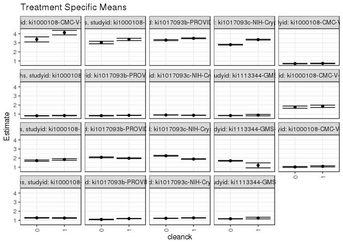

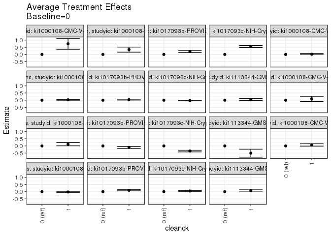

## Results Table

### Parameter: TSM

| agecat | studyid | country | intervention_level | baseline_level | estimate | ci_lower | ci_upper |
| --- | --- | --- | --- | --- | --- | --- | --- |
| 0-3 months | ki1000108-CMC-V-BCS-2002 | INDIA | 0 | NA | 3.3733467 | 3.0963379 | 3.6503556 |
| 0-3 months | ki1000108-CMC-V-BCS-2002 | INDIA | 1 | NA | 4.1155737 | 3.8673952 | 4.3637521 |
| 0-3 months | ki1000108-IRC | INDIA | 0 | NA | 3.0319322 | 2.8912931 | 3.1725713 |
| 0-3 months | ki1000108-IRC | INDIA | 1 | NA | 3.3707250 | 3.2449458 | 3.4965042 |
| 0-3 months | ki1017093b-PROVIDE | BANGLADESH | 0 | NA | 3.2968250 | 3.2403625 | 3.3532875 |
| 0-3 months | ki1017093b-PROVIDE | BANGLADESH | 1 | NA | 3.4926253 | 3.4517085 | 3.5335422 |
| 0-3 months | ki1017093c-NIH-Crypto | BANGLADESH | 0 | NA | 2.7931373 | 2.7515704 | 2.8347042 |
| 0-3 months | ki1017093c-NIH-Crypto | BANGLADESH | 1 | NA | 3.3471310 | 3.3012275 | 3.3930345 |
| 3-6 months | ki1000108-CMC-V-BCS-2002 | INDIA | 0 | NA | 1.7645096 | 1.6402538 | 1.8887653 |
| 3-6 months | ki1000108-CMC-V-BCS-2002 | INDIA | 1 | NA | 1.8555831 | 1.7262007 | 1.9849655 |
| 3-6 months | ki1000108-IRC | INDIA | 0 | NA | 1.7237635 | 1.6524782 | 1.7950487 |
| 3-6 months | ki1000108-IRC | INDIA | 1 | NA | 1.8461319 | 1.7597797 | 1.9324840 |
| 3-6 months | ki1017093b-PROVIDE | BANGLADESH | 0 | NA | 2.0840782 | 2.0340861 | 2.1340702 |
| 3-6 months | ki1017093b-PROVIDE | BANGLADESH | 1 | NA | 1.9808528 | 1.9421479 | 2.0195576 |
| 3-6 months | ki1017093c-NIH-Crypto | BANGLADESH | 0 | NA | 2.2554555 | 2.2098972 | 2.3010139 |
| 3-6 months | ki1017093c-NIH-Crypto | BANGLADESH | 1 | NA | 1.8969116 | 1.8593661 | 1.9344570 |
| 3-6 months | ki1113344-GMS-Nepal | NEPAL | 0 | NA | 1.7029460 | 1.6611673 | 1.7447248 |
| 3-6 months | ki1113344-GMS-Nepal | NEPAL | 1 | NA | 1.1971202 | 0.9221346 | 1.4721057 |
| 6-12 months | ki1000108-CMC-V-BCS-2002 | INDIA | 0 | NA | 1.0232064 | 0.9700242 | 1.0763885 |
| 6-12 months | ki1000108-CMC-V-BCS-2002 | INDIA | 1 | NA | 1.0926338 | 1.0286858 | 1.1565819 |
| 6-12 months | ki1000108-IRC | INDIA | 0 | NA | 1.2708703 | 1.2391288 | 1.3026118 |
| 6-12 months | ki1000108-IRC | INDIA | 1 | NA | 1.2513309 | 1.2146088 | 1.2880530 |
| 6-12 months | ki1017093b-PROVIDE | BANGLADESH | 0 | NA | 1.0913105 | 1.0586260 | 1.1239951 |
| 6-12 months | ki1017093b-PROVIDE | BANGLADESH | 1 | NA | 1.1897074 | 1.1707316 | 1.2086832 |
| 6-12 months | ki1017093c-NIH-Crypto | BANGLADESH | 0 | NA | 1.2172541 | 1.1993149 | 1.2351933 |
| 6-12 months | ki1017093c-NIH-Crypto | BANGLADESH | 1 | NA | 1.2641642 | 1.2429665 | 1.2853618 |
| 6-12 months | ki1113344-GMS-Nepal | NEPAL | 0 | NA | 1.1670633 | 1.1458683 | 1.1882583 |
| 6-12 months | ki1113344-GMS-Nepal | NEPAL | 1 | NA | 1.2448902 | 1.1538939 | 1.3358864 |
| 12-24 months | ki1000108-CMC-V-BCS-2002 | INDIA | 0 | NA | 0.7132015 | 0.6855280 | 0.7408751 |
| 12-24 months | ki1000108-CMC-V-BCS-2002 | INDIA | 1 | NA | 0.7311910 | 0.6988917 | 0.7634902 |
| 12-24 months | ki1000108-IRC | INDIA | 0 | NA | 0.8148498 | 0.7951855 | 0.8345142 |
| 12-24 months | ki1000108-IRC | INDIA | 1 | NA | 0.8391024 | 0.8153769 | 0.8628279 |
| 12-24 months | ki1017093b-PROVIDE | BANGLADESH | 0 | NA | 0.8267682 | 0.7998776 | 0.8536589 |
| 12-24 months | ki1017093b-PROVIDE | BANGLADESH | 1 | NA | 0.8640655 | 0.8508092 | 0.8773218 |
| 12-24 months | ki1017093c-NIH-Crypto | BANGLADESH | 0 | NA | 0.8964113 | 0.8837597 | 0.9090630 |
| 12-24 months | ki1017093c-NIH-Crypto | BANGLADESH | 1 | NA | 0.8709037 | 0.8578908 | 0.8839166 |
| 12-24 months | ki1113344-GMS-Nepal | NEPAL | 0 | NA | 0.8392162 | 0.8226336 | 0.8557987 |
| 12-24 months | ki1113344-GMS-Nepal | NEPAL | 1 | NA | 0.8847746 | 0.8100688 | 0.9594805 |

### Parameter: E(Y)

| agecat | studyid | country | intervention_level | baseline_level | estimate | ci_lower | ci_upper |
| --- | --- | --- | --- | --- | --- | --- | --- |
| 0-3 months | ki1000108-CMC-V-BCS-2002 | INDIA | NA | NA | 3.5235318 | 3.3031217 | 3.7439420 |
| 0-3 months | ki1000108-IRC | INDIA | NA | NA | 3.1808197 | 3.0676645 | 3.2939748 |
| 0-3 months | ki1017093b-PROVIDE | BANGLADESH | NA | NA | 3.4826706 | 3.4434873 | 3.5218539 |
| 0-3 months | ki1017093c-NIH-Crypto | BANGLADESH | NA | NA | 3.3125346 | 3.2707547 | 3.3543144 |
| 3-6 months | ki1000108-CMC-V-BCS-2002 | INDIA | NA | NA | 1.8037880 | 1.7029866 | 1.9045894 |
| 3-6 months | ki1000108-IRC | INDIA | NA | NA | 1.8807708 | 1.8161067 | 1.9454349 |
| 3-6 months | ki1017093b-PROVIDE | BANGLADESH | NA | NA | 1.9654454 | 1.9303798 | 2.0005110 |
| 3-6 months | ki1017093c-NIH-Crypto | BANGLADESH | NA | NA | 2.0125524 | 1.9699507 | 2.0551541 |
| 3-6 months | ki1113344-GMS-Nepal | NEPAL | NA | NA | 1.6958254 | 1.6540818 | 1.7375690 |
| 6-12 months | ki1000108-CMC-V-BCS-2002 | INDIA | NA | NA | 1.0624474 | 1.0146679 | 1.1102268 |
| 6-12 months | ki1000108-IRC | INDIA | NA | NA | 1.2448229 | 1.2160865 | 1.2735593 |
| 6-12 months | ki1017093b-PROVIDE | BANGLADESH | NA | NA | 1.1731762 | 1.1558671 | 1.1904853 |
| 6-12 months | ki1017093c-NIH-Crypto | BANGLADESH | NA | NA | 1.2387386 | 1.2183403 | 1.2591370 |
| 6-12 months | ki1113344-GMS-Nepal | NEPAL | NA | NA | 1.1687097 | 1.1476895 | 1.1897299 |
| 12-24 months | ki1000108-CMC-V-BCS-2002 | INDIA | NA | NA | 0.7397013 | 0.7128622 | 0.7665404 |
| 12-24 months | ki1000108-IRC | INDIA | NA | NA | 0.8300487 | 0.8102720 | 0.8498253 |
| 12-24 months | ki1017093b-PROVIDE | BANGLADESH | NA | NA | 0.8575519 | 0.8455586 | 0.8695452 |
| 12-24 months | ki1017093c-NIH-Crypto | BANGLADESH | NA | NA | 0.8863476 | 0.8737443 | 0.8989509 |
| 12-24 months | ki1113344-GMS-Nepal | NEPAL | NA | NA | 0.8399109 | 0.8235241 | 0.8562976 |

### Parameter: ATE

| agecat | studyid | country | intervention_level | baseline_level | estimate | ci_lower | ci_upper |
| --- | --- | --- | --- | --- | --- | --- | --- |
| 0-3 months | ki1000108-CMC-V-BCS-2002 | INDIA | 0 | 0 | 0.0000000 | 0.0000000 | 0.0000000 |
| 0-3 months | ki1000108-CMC-V-BCS-2002 | INDIA | 1 | 0 | 0.7422270 | 0.3650385 | 1.1194154 |
| 0-3 months | ki1000108-IRC | INDIA | 0 | 0 | 0.0000000 | 0.0000000 | 0.0000000 |
| 0-3 months | ki1000108-IRC | INDIA | 1 | 0 | 0.3387928 | 0.1619938 | 0.5155919 |
| 0-3 months | ki1017093b-PROVIDE | BANGLADESH | 0 | 0 | 0.0000000 | 0.0000000 | 0.0000000 |
| 0-3 months | ki1017093b-PROVIDE | BANGLADESH | 1 | 0 | 0.1958003 | 0.1287484 | 0.2628523 |
| 0-3 months | ki1017093c-NIH-Crypto | BANGLADESH | 0 | 0 | 0.0000000 | 0.0000000 | 0.0000000 |
| 0-3 months | ki1017093c-NIH-Crypto | BANGLADESH | 1 | 0 | 0.5539937 | 0.4890834 | 0.6189040 |
| 3-6 months | ki1000108-CMC-V-BCS-2002 | INDIA | 0 | 0 | 0.0000000 | 0.0000000 | 0.0000000 |
| 3-6 months | ki1000108-CMC-V-BCS-2002 | INDIA | 1 | 0 | 0.0910736 | -0.0882814 | 0.2704285 |
| 3-6 months | ki1000108-IRC | INDIA | 0 | 0 | 0.0000000 | 0.0000000 | 0.0000000 |
| 3-6 months | ki1000108-IRC | INDIA | 1 | 0 | 0.1223684 | 0.0094625 | 0.2352743 |
| 3-6 months | ki1017093b-PROVIDE | BANGLADESH | 0 | 0 | 0.0000000 | 0.0000000 | 0.0000000 |
| 3-6 months | ki1017093b-PROVIDE | BANGLADESH | 1 | 0 | -0.1032254 | -0.1665976 | -0.0398531 |
| 3-6 months | ki1017093c-NIH-Crypto | BANGLADESH | 0 | 0 | 0.0000000 | 0.0000000 | 0.0000000 |
| 3-6 months | ki1017093c-NIH-Crypto | BANGLADESH | 1 | 0 | -0.3585439 | -0.4167557 | -0.3003321 |
| 3-6 months | ki1113344-GMS-Nepal | NEPAL | 0 | 0 | 0.0000000 | 0.0000000 | 0.0000000 |
| 3-6 months | ki1113344-GMS-Nepal | NEPAL | 1 | 0 | -0.5058259 | -0.7838461 | -0.2278057 |
| 6-12 months | ki1000108-CMC-V-BCS-2002 | INDIA | 0 | 0 | 0.0000000 | 0.0000000 | 0.0000000 |
| 6-12 months | ki1000108-CMC-V-BCS-2002 | INDIA | 1 | 0 | 0.0694275 | -0.0122268 | 0.1510818 |
| 6-12 months | ki1000108-IRC | INDIA | 0 | 0 | 0.0000000 | 0.0000000 | 0.0000000 |
| 6-12 months | ki1000108-IRC | INDIA | 1 | 0 | -0.0195394 | -0.0678547 | 0.0287759 |
| 6-12 months | ki1017093b-PROVIDE | BANGLADESH | 0 | 0 | 0.0000000 | 0.0000000 | 0.0000000 |
| 6-12 months | ki1017093b-PROVIDE | BANGLADESH | 1 | 0 | 0.0983969 | 0.0606096 | 0.1361841 |
| 6-12 months | ki1017093c-NIH-Crypto | BANGLADESH | 0 | 0 | 0.0000000 | 0.0000000 | 0.0000000 |
| 6-12 months | ki1017093c-NIH-Crypto | BANGLADESH | 1 | 0 | 0.0469101 | 0.0225000 | 0.0713202 |
| 6-12 months | ki1113344-GMS-Nepal | NEPAL | 0 | 0 | 0.0000000 | 0.0000000 | 0.0000000 |
| 6-12 months | ki1113344-GMS-Nepal | NEPAL | 1 | 0 | 0.0778268 | -0.0150426 | 0.1706963 |
| 12-24 months | ki1000108-CMC-V-BCS-2002 | INDIA | 0 | 0 | 0.0000000 | 0.0000000 | 0.0000000 |
| 12-24 months | ki1000108-CMC-V-BCS-2002 | INDIA | 1 | 0 | 0.0179894 | -0.0227809 | 0.0587598 |
| 12-24 months | ki1000108-IRC | INDIA | 0 | 0 | 0.0000000 | 0.0000000 | 0.0000000 |
| 12-24 months | ki1000108-IRC | INDIA | 1 | 0 | 0.0242525 | -0.0034257 | 0.0519308 |
| 12-24 months | ki1017093b-PROVIDE | BANGLADESH | 0 | 0 | 0.0000000 | 0.0000000 | 0.0000000 |
| 12-24 months | ki1017093b-PROVIDE | BANGLADESH | 1 | 0 | 0.0372972 | 0.0073524 | 0.0672421 |
| 12-24 months | ki1017093c-NIH-Crypto | BANGLADESH | 0 | 0 | 0.0000000 | 0.0000000 | 0.0000000 |
| 12-24 months | ki1017093c-NIH-Crypto | BANGLADESH | 1 | 0 | -0.0255077 | -0.0425592 | -0.0084561 |
| 12-24 months | ki1113344-GMS-Nepal | NEPAL | 0 | 0 | 0.0000000 | 0.0000000 | 0.0000000 |
| 12-24 months | ki1113344-GMS-Nepal | NEPAL | 1 | 0 | 0.0455584 | -0.0309128 | 0.1220297 |